# test

Nicholas Nagle

January 26, 2015

# Homework 1

Ian Morris

February 2, 2015

# INSTRUCTIONS:

Edit this file by replacing the instructions with text and code to anser the questions. I should be able to knit this file and reproduce the html, pdf, or word document.

A block to load in the data:

```r
rm(list=ls()) # Clean the workspace to be empty
arbuthnot <- read.csv('/Users/nnagle/Dropbox/git_root/homework/homework1/data/arbuthnot.csv')
```

# Question 1

This is a question about how the axes affects how we interpret plots.

Create two plots of Male-Female Christenings, one in which the y-axis scale is set by default, and one in which the y-axis extends all the way to zero. Yes, I know that was in the tutorial. I want to see it here.

- Describe the visual appearance of the two plots. Do they “feel” like they describe the same data?
- Describe how you might be able to mislead readers by changing the scaling on graphs.
- Which plot seems more appropriate here? Why?

# Question 2

This question is designed to give you some practice with ggplot as well as describing plots in words.

Use ggplot to create a scatterplot that has Female christenings on the x-axis and Male christenings on the y-axis. Draw a 45 degree line (using geom_abline) to show the line where Male and Female christenings are equal. Use this figure to describe the relationship and distribution of Male and Female christenings.

# Question 3

This is a question about population, sample, representativeness and generalizability.

How do you think the christenings-based sample would compared to a births-based sample? Similar? Different? Why? Arbuthnot’s data probably included most every christening in London during this period; they probably aren’t any unreported christenings. Is this fact important? Why or why not? Would a christenings based sample be appropriate now, in the 21st century? (Hint, this last question is trickier than it might seem. Think about what causes Male/Female Births, what causes people to christen their children, and any relations or not between these)

# Question 4

What does “sex ratio at birth” mean? How does it depend on biology, cuture and technology. Consider the three cases of 1) late 17th century England, 2) 21st century US, and China under the [one-child policy](http://en.wikipedia.org/wiki/One-child_policy).

# Question 5

The purpose of this quetion is to give you a little practice using standard deviation.

1. The average height of young women ages 18-24 is 64.5 in. The distribution of heights is approximately normal (Gaussian) with a standardard deviation of $\sigma=2.5$. Complete this sentence: Approximately 95% of women have a height greater than ______ in and less than ______ in.

```r
library(ggplot2)
rm(list=ls()) # Clean the workspace to be empty
arbuthnot <- read.csv('/Users/ianmorris/Desktop/GEOG415/imorris1/homework1/data/arbuthnot.csv')
```

# Question 1

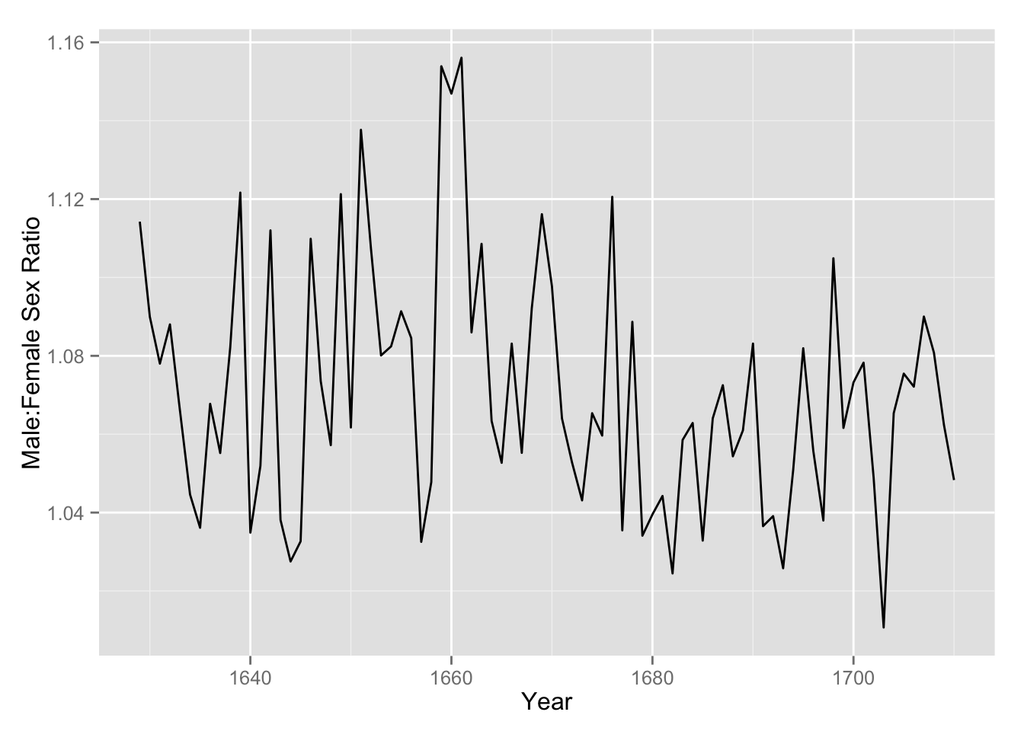

```r
ggplot(data=arbuthnot) +
     geom_line(aes(x=Year, y=Males/Females))+
     ylab('Male:Female Sex Ratio')
```

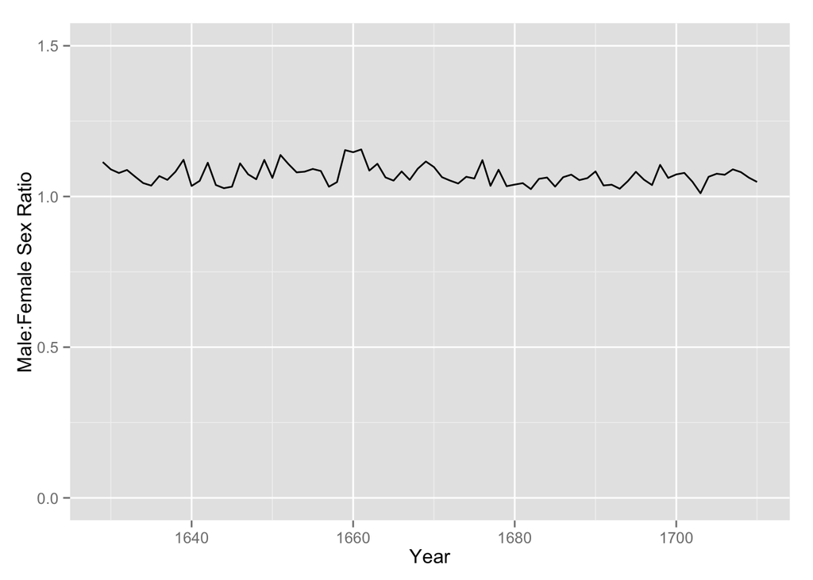

```r
ggplot(data=arbuthnot) +
  geom_line(aes(x=Year, y=Males/Females))+
  scale_y_continuous(limits=c(0, 1.5)) +
  ylab('Male:Female Sex Ratio')
```

In the plot with the default y-axis, the differences in the annual sex ratio seem much more extreme. When the y-axis is set from 0 to 1.5, the annual variation seems much smaller. It generally appears to stay generally the same, just above 1.0, in the 0 to 1.5 plot, where in the default y-axis plot, it seems as if there are huge annual variations. So, they do not “feel” like they are describing the same data because of how large the swings appear to be in the default y-axis plot.

If you were to create a graph in which the y-axis had a very narrow range, it would be easy to make the data appear to have huge shifts even if they were relatively small. On the other extreme, if you were to make the y-axis have an inappropriately-large range, the differences in the data would seem too modest and wouldn’t give an accurate representation of how the data changes.

The plot with the y-axis existing from 0 to 1.5 seems more appropriate here. Although there are some small annual variations in the sex ratio at birth, they aren’t nearly as extreme as the default y-axis plot makes them appear to be.

# Question 2

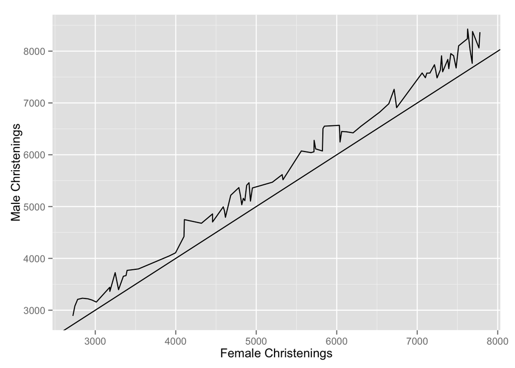

```r
ggplot(data=arbuthnot) + geom_line(aes(x=Females, y=Males)) + ylab('Male Christenings') + xlab('Female Christenings') + geom_abline(slope = 1)
```

Given that a 45 degree line has a slope of 1, meaning that one male would be christened for every female christened, we can see that there are slightly more males born annually than females throughout the length of Arbuthnot’s study. This shows that as more females are born, more males are also born, and vice versa. In some years, the ratio approached the 45 degree line and came very close to it, but in other years, the number of males born as compared to females spiked to a ratio of above 1.1:1. There is some variation in the ratio, but this plot shows that male births rise proportionately with female births, in general, and that slightly more males were christened on an annual basis than females.

# Question 3

I think that the christenings-based sample would be quite similar to one based on births, but there would be some slight difference. I imagine that only infants who survived for more than a few days were christened in this time period, and that infants who died right after birth would not have been included in this sample. Males are more likely to die in infancy than females are, so the actual ratio of males born to females born could be even more skewed towards males. However, there could also be issues that would skew the data towards males in the christenings-based sample, as males were culturally preferred in the 17th century, and it’s possible that girls that were not desired by a family could have been not christened or even killed. It’s important that Arbuthnot’s data included most all christenings in London because the sample size is larger, and thus, more representative of reality. If Arbuthnot’s sample were to have been smaller, there would have been more uncertainty about the validity of the sample. A christenings-based sample wouldn’t be as appropriate today, because fewer parents christen their children. Generally, only church-going Christian families christen their children, and the ratio of males to females in that particular population would probably be different than if one’s desire were to acquire a representative sample for all people. For example, in certain cultures, there is a strong preference for male children over females to this day. Because of this, infanticide and sex-based abortions prop up the number of males born to females. A christenings-based sample would not fully incorporate this particular section of society into its sample. Also, it’s possible that there are environmental factors that could cause a certain group of people to produce a disproportionately high number of females or males, and it’s possible that this group wouldn’t be included in a christenings-based sample. In this day and age, it would be important to use a sample that includes all different groups.